# Distribution Theory

BMLR Chapters 3 and 5

Author

Affiliation

Ann Cannon

Cornell College  
STA 363 Fall 2026 Block 1

# Chapter 3 - Distribution Theory

## Learning Objectives

- Write definitions of non-normal random variables in the context of an application.
- Identify possible values for each random variable.
- Identify how changing values for a parameter affects the characteristics of the distribution.
- Recognize a form of the probability density function for each distribution.
- Identify the mean and variance for each distribution.
- Match the response for a study to a plausible random variable and provide reasons for ruling out other random variables.
- Match a histogram of sample data to plausible distributions.
- Create a mixture of distributions and evaluate the shape, mean, and variance.

## Libraries Needed

```r
# Packages required for Chapter 3
library(gridExtra)
library(knitr)
library(kableExtra)
library(tidyverse)
library(tidymodels)
library(GGally)
library(knitr)
library(patchwork)
library(viridis)
library(ggfortify)
```

## Introduction

- What if it is not plausible that a response is normally distributed?
- You may want to construct a model to predict whether a prospective student will enroll at a school or model the lifetimes of patients following a particular surgery.
- In the first case you have a binary response (enrolls (1) or does not enroll (0)), and in the second case you are likely to have very skewed data with many similar values and a few hardy souls with extremely long survival.
- These responses are not expected to be normally distributed; other distributions will be needed to describe and model binary or lifetime data.
- Non-normal responses are encountered in a large number of situations. Luckily, there are quite a few possibilities for models.
- All information in this chapter is covered in much greater depth in STA 347.

# Discrete Random Variables

## Discrete Random Variables

- A discrete random variable has a countable number of possible values
  - Ex: we may want to measure the number of people in a household
  - Ex: model the number of crimes committed on a college campus.
- With discrete random variables, the associated probabilities can be calculated for each possible value using a **probability mass function** (pmf).
- A pmf is a function that calculates $P(Y=y)$, given each variable’s parameters.
- We use $\operatorname{E}(Y)=\mu$ to represent the mean of the distribution
- We use $\operatorname{SD}(Y)=\sigma$ to represent the standard deviation of the distribution

## Binary Random Variable

- Consider the event of flipping a (possibly unfair) coin.
- If the coin lands heads, let’s consider this a success and record $Y = 1$.
- If the coin lands tails, then we record $Y=0$.
- A series of these events is a **Bernoulli process** if these events consist of
  - independent trials
  - each trial takes on one of two values (e.g., 0 or 1).
  - the probability of success is identical for each trial.
- Typically we refer to the value 0 as a failure and the value of 1 as a success.

## Binary Random Variable

- Suppose we only flip the coin once, so we only have one parameter, the probability of flipping heads, $p$.
- If we know this value, we can express $P(Y=1) = p$ and $P(Y=0) = 1-p$.
- In general, if we have a Bernoulli process with only one trial, we have a **binary distribution** (also called a **Bernoulli distribution**) where

. . .

$$\begin{equation*}
P(Y = y) = p^y(1-p)^{1-y} \quad \textrm{for} \quad y = 0, 1.
\end{equation*}$$

- If $Y \sim \textrm{Binary}(p)$ , then $Y$ has mean $\operatorname{E}(Y) = p$ and standard deviation $\operatorname{SD}(Y) = \sqrt{p(1-p)}$.

## Example 1

- Your playlist of 200 songs has 5 which you cannot stand. What is the probability that when you hit shuffle, a song you tolerate comes on?
- We want to understand the example and be able to translate that into notation/model it with a distribution
- Assuming all songs have equal odds of playing, we can calculate $p = \frac{200-5}{200} = 0.975$
  - so there is a 97.5% chance of a song you tolerate playing, since $P(Y=1)=.975^1*(1-.975)^0$.

## Binomial Random Variable (1/2)

- We can extend our knowledge of binary random variables.
- Suppose we flipped an *unfair* coin $n$ times and recorded $Y$, the number of heads after $n$ flips.
- If we consider a case where $p = 0.25$ and $n = 4$, then here $P(Y=0)$ represents the probability of no successes in 4 trials (no heads in 4 flips)
  - 4 consecutive failures.
  - The probability of 4 consecutive failures is $P(Y = 0) = P(TTTT) = (1-p)^4 = 0.75^4$.

## Binomial Random Variable (2/2)

- Next we consider $P(Y = 1)$, and are interested in the probability of exactly 1 success *anywhere* among the 4 trials.
- There are several ways to get exactly 1 success in 4 trials. What is the probability for one way of these ways?
- To find the total probability of getting exactly 1 success among the 4 trials what else do we need to count?
- There are $\binom{4}{1} = \frac{4!}{1!(4-1)!}=4$ ways to have exactly 1 success in 4 trials, $P(Y = 1) = \binom{4}{1}p^1(1-p)^{4-1} = (4)(0.25)(0.75)^3$.

## Binomial Distribution

- In general, if we carry out a sequence of $n$ Bernoulli trials (with probability of success $p$) and record $Y$, the total number of successes, then $Y$ follows a **binomial distribution**, where

. . .

$$\begin{equation}
P(Y=y) = \binom{n}{y} p^y (1-p)^{n-y} \quad \textrm{for} \quad y = 0, 1, \ldots, n.
\end{equation}$$

. . .

- If $Y \sim \textrm{Binomial}(n,p)$, then $\operatorname{E}(Y) = np$ and $\operatorname{SD}(Y) = \sqrt{np(1-p)}$.
- $E(y)$ is the expected value of $Y$. If we repeated the experiment many times we would expect on average $n*p$ successes.

## Binomial Distribution Graphs

- Typical shapes of a binomial distribution
- I will show you these in R

## Binomial Distribution vs Bernoulli

- Note that if $n=1$,

. . .

$$\begin{align*}
P(Y=y) &= \binom{1}{y} p^y(1-p)^{1-y} \\
&= p^y(1-p)^{1-y}\quad \textrm{for}\quad y = 0, 1,
\end{align*}$$
a Bernoulli distribution!

- In fact, Bernoulli random variables are a special case of binomial random variables where $n=1$.

## Graphing/calling in R

- In R we can use the function `dbinom(y, n, p)`, which outputs the probability of $y$ successes given $n$ trials with probability $p$, i.e., $P(Y=y)$ for $Y \sim \textrm{Binomial}(n,p)$.
- Lets try it

## Example 2 (1/2)

- While taking a multiple choice test, a student encountered 10 problems where she ended up completely guessing, randomly selecting one of the four options.
- What is the chance that she got exactly 2 of the 10 correct?
- What assumption do we need to make about the questions?
- How would we do this without using a distribution?

## Example 2 (2/2)

- Knowing that the student randomly selected her answers, we assume she has a 25% chance of a correct response.
- n *factorial* is denoted $n!$ and $n!=n\cdot(n-1)\cdot...\cdot 3\cdot 2\cdot 1$
- Here we used a *combination* ${n \choose p}=\frac{n!}{p!(n-p)!}$ read *n choose p*
- Thus, $P(Y=2) = {10 \choose 2}(.25)^2(.75)^8 = 0.282$.

. . .

- We can use R to verify this:

. . .

```r
dbinom(2, size = 10, prob = .25)
```

```
[1] 0.2815676
```

Therefore, there is a 28% chance of exactly 2 correct answers out of 10.

## Negative Binomial Random Variable

- What if we were to carry out multiple independent and identical Bernoulli trails until the $r$<sup>th</sup> success occurs?
- If we model $Y$, the number of failures before the $r$<sup>th</sup> success, then $Y$ follows a **negative binomial distribution** where

. . .

$$\begin{equation}
P(Y=y) = \binom{y + r - 1}{r-1} (1-p)^{y}(p)^r \quad \textrm{for}\quad y = 0, 1, \ldots, \infty.
\end{equation}$$

## Negative Binomial RV

- If $Y \sim \textrm{Negative Binomial}(r, p)$ then $E(Y) = \frac{r(1-p)}{p}$ and $\operatorname{SD}(Y) = \sqrt{\frac{r(1-p)}{p^2}}$.
- R function `dnbinom(y, r, p)` for the probability of $y$ failures before the $r$<sup>th</sup> success given probability $p$.

## Negative Binomial RV

**Plot**

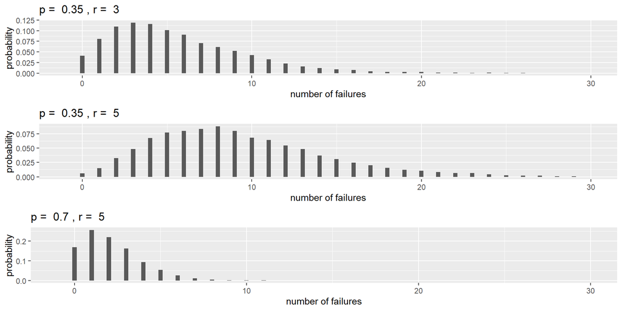

Negative Binomial

- Notice how centers shift right as $r$ increases, and left as $p$ increases.

**Code**

```r
#negativeBinomialPlots
plotNBinom <- function(p, r){
  ynb <- 0:10000
  nbd <- tibble(x = rnbinom(ynb, r, p))
  #breaks <- pretty(range(nbd$x), n = nclass.FD(nbd$x), min.n = 1)  # pretty binning
  #bwidth <- breaks[2] - breaks[1]
  ggplot(nbd, aes(x = x)) +
    geom_histogram(aes(y=..count../sum(..count..)), binwidth = .25) +
    labs(title = paste("p = ", p, ", r = ", r),
         x = "number of failures",
         y = "probability") +
    xlim(-1,30)
}

NBin1 <- plotNBinom(0.35, 3)
NBin2 <- plotNBinom(0.35, 5)
NBin3 <- plotNBinom(0.70, 5)
grid.arrange(NBin1, NBin2, NBin3, ncol = 1)
```

## Poisson Random Variable

- Sometimes, random variables are based on a **Poisson process**.
- In a Poisson process, we are counting the number of events per unit of time or space and the number of events depends only on the length or size of the interval.
- We can then model $Y$, the number of events in one of these sections with the **Poisson distribution**, where

. . .

$$\begin{equation}
P(Y=y) = \frac{e^{-\lambda}\lambda^y}{y!} \quad \textrm{for} \quad y = 0, 1, \ldots, \infty,
\end{equation}$$
where $\lambda$ is the mean or expected count in the unit of time or space of interest. - This probability mass function has $\operatorname{E}(Y) = \lambda$ and $\operatorname{SD}(Y) = \sqrt{\lambda}$.

## Poisson Distribution Graphs

**Plot**

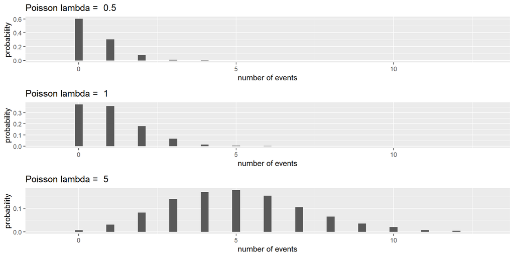

- Notice how distributions become more symmetric as $\lambda$ increases.
- If we wish to use R, `dpois(y, lambda)` outputs the probability of $y$ events given $\lambda$.

**Code**

```r
#poissonPlots
plotPois <- function(lam){
yp = 0:10000 # possible values
pd <- data.frame(x=rpois(yp, lam))  # generate random deviates
breaks <- pretty(range(pd$x), n = nclass.FD(pd$x), min.n = 1)  # pretty binning
#bwidth <- breaks[2] - breaks[1]
ggplot(pd, aes(x = x)) + geom_histogram(aes(y=..count../sum(..count..)), binwidth = .25) +
  xlab("number of events") + ylab("probability") +
  labs(title=paste("Poisson lambda = ", lam)) + xlim(-1,13)
}

Pois1 <- plotPois(0.5)
Pois2 <- plotPois(1)
Pois3 <- plotPois(5) + scale_y_continuous(breaks = c(0, 0.1))
grid.arrange(Pois1,Pois2,Pois3,ncol=1)
```

# Continuous Random Variables

## Continuous Random Variables

- A continuous random variable can take on an uncountably infinite number of values.
- With continuous random variables, we define probabilities using **probability density functions** (pdfs).
- Probabilities are calculated by computing the area under the density curve over the interval of interest. So, given a pdf, $f(y)$, we can compute

. . .

$$\begin{align*}
P(a \le Y \le b) = \int_a^b f(y)dy.
\end{align*}$$

## Continuous Random Variables

A few properties of continuous random variables:

- The area under their density curve is 1. ($\int_{-\infty}^{\infty} f(y)dy = 1$).
- For any value $y$, $P(Y = y) = \int_y^y f(y)dy = 0$. Why?
- Because of the above property, $P(y < Y) = P(y \le Y)$. We will typically use the first notation rather than the second, but both are equally valid.

## Exponential Random Variable

- Suppose we have a Poisson process with rate $\lambda$, and we wish to model the wait time $Y$ until the first event.
- We could model $Y$ using an **exponential distribution**, where

. . .

$$\begin{equation}
f(y) = \lambda e^{-\lambda y} \quad \textrm{for} \quad y > 0,
\end{equation}$$
- $\operatorname{E}(Y) = 1/\lambda$ and $\operatorname{SD}(Y) = 1/\lambda$.

## Exponential Distribution

Exponential distributions with $\lambda = 0.5, 1,$ and $5$.

**Plot**

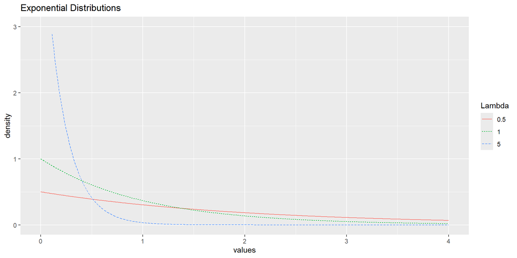

Exponential Distribution

- As $\lambda$ increases, $\operatorname{E}(Y)$ tends towards 0, and distributions “die off” quicker.

**Code**

```r
#exponentialPlots
x=seq(0,4,by=0.01)  # possible values
probex1 <- dexp(x,.5)  # P(Y=y)
probex2 <- dexp(x,1)
probex3 <- dexp(x,5)
Expdf <- tibble(x,probex1, probex2, probex3) %>%
  rename(x = x,
         `0.5` = probex1,
         `1` = probex2,
         `5` = probex3) %>%
  gather(2:4, key = "Lambda", value = "value") %>%
  mutate(Lambda = factor(Lambda, levels = c("0.5", "1", "5")))
ggplot(data = Expdf, aes(x = x, y = value, color = Lambda)) +
  geom_line(aes(linetype = Lambda)) +
  xlab("values") + ylab("density") +
  labs(title = "Exponential Distributions") +
  xlim(0,4) + ylim(0,3)
```

- To use R, `pexp(y, lambda)` outputs the probability $P(Y < y)$ given $\lambda$.

## Gamma Random Variable

- Once again consider a Poisson process.
- When discussing exponential random variables, we modeled the wait time before one event occurred.
- If $Y$ represents the wait time before $r$ events occur in a Poisson process with rate $\lambda$, $Y$ follows a **gamma distribution** where

. . .

$$\begin{equation}
f(y) = \frac{\lambda^r}{\Gamma(r)} y^{r-1} e^{-\lambda y}\quad \textrm{for} \quad y >0.
\end{equation}$$

- If $Y \sim \textrm{Gamma}(r, \lambda)$ then $\operatorname{E}(Y) = r/\lambda$ and $\operatorname{SD}(Y) = \sqrt{r/\lambda^2}$.
- Note: If r is an integer, then $\Gamma(r)=(r-1)!$ (There is more to it)

## Gamma Distribution

**Plot**

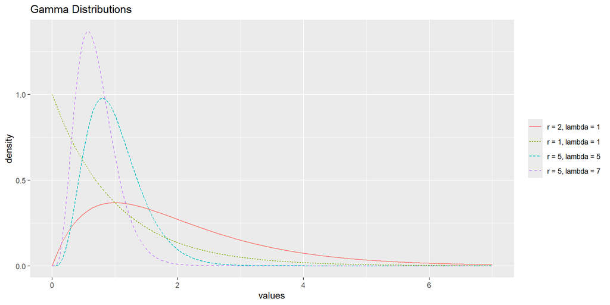

- Means increase as $r$ increases, but decrease as $\lambda$ increases.

**Code**

```r
x <- seq(0, 7, by = 0.01)
`r = 1, lambda = 1` <- dgamma(x, 1, rate = 1)
`r = 2, lambda = 1` <- dgamma(x, 2, rate = 1)
`r = 5, lambda = 5` <- dgamma(x, 5, rate = 5)
`r = 5, lambda = 7` <- dgamma(x, 5, rate = 7)

gammaDf <- tibble(x, `r = 1, lambda = 1`, `r = 2, lambda = 1`, `r = 5, lambda = 5`, `r = 5, lambda = 7`) %>%
  gather(2:5, key = "Distribution", value = "value") %>%
  mutate(Distribution = factor(Distribution,
                               levels = c("r = 2, lambda = 1",
                                          "r = 1, lambda = 1",
                                          "r = 5, lambda = 5",
                                          "r = 5, lambda = 7")))

ggplot(data = gammaDf, aes(x = x, y = value,
                           color = Distribution)) +
  geom_line(aes(linetype = Distribution)) +
  xlab("values") + ylab("density") +
  labs(title = "Gamma Distributions") +
  theme(legend.title = element_blank())
```

## Gamma vs Others

- Note that if we let $r = 1$, we have the following pdf,

. . .

$$\begin{align*}
f(y) &= \frac{\lambda}{\Gamma(1)} y^{1-1} e^{-\lambda y} \\
&= \lambda e^{-\lambda y} \quad \textrm{for} \quad y > 0,
\end{align*}$$
an exponential distribution.

- Exponential distributions are in fact a special case of gamma distributions!
- Just like negative binomial, the pdf of a gamma distribution is defined for all real, non-negative $r$.
- In R, `pgamma(y, r, lambda)` outputs the probability $P(Y < y)$ given $r$ and $\lambda$.

## Distributions Used in Testing

- We have spent most of this chapter discussing probability distributions that may come in handy when modeling.
- The following distributions, while rarely used in modeling, prove useful in hypothesis testing as certain commonly used test statistics follow these distributions.
- $\chi^2$ distribution (requires a degree of freedom)
- Student’s $t$ distribution
- $F$ distribution (need 2 different degrees of freedom)
- Since we have used these in the past, we will leave their definitions to be referenced if needed

## Distribution Table!

- Would not fit on a slide
- Click [HERE](https://bookdown.org/roback/bookdown-BeyondMLR/ch-distthry.html#tab:distTable)
- The “web” of distributions: https://www.acsu.buffalo.edu/~adamcunn/probability/poisson.html

## Acknowledgements

- These slides are based on content in [BMLR: Chapter 3 - Distribution Theory](https://bookdown.org/roback/bookdown-BeyondMLR/ch-distthry.html)
- Edited from slides by Tyler George

# Chapter 5 - Generalized Linear Models

## Learning goals

- Explain the use of generalized linear models
- Identify the components common to all generalized linear models
- Find the canonical link based on the distribution of the response variable

# General Linear Models (GLMs)

## Why are GLMs useful?

- Linear regression models are used to predict $\mu_{y|x}$.
  - We assume that $Y$ has a normal distribution with mean $\mu_{y|x}$ and variance $\sigma^2$.
  - The model we use is $\mu_{y|x}=\beta_0 + \beta_1~x_1 + \beta_2~x_2 +...$
  - Note the unknown parameter is on the left and a linear combination of the predictor variables is on the right.
- What if the response variable $Y$ doesn’t have a normal distribution? Can we estimate a relevant parameter of its actual distribution?
- If a GLM exists, then it gives us a way of estimating the relevant parameter using a linear combination of the predictor variables.

## Many models; one family

We will see three different situations where glms are appropriate:

- linear regression (response has a Normal distribution)
- logistic regression (response has a Bernoulli or Binomial distribution)
- poisson regression (response has a Poisson or Negative Binomial distribution)

. . .

All of these cases lead to models that are examples of **generalized linear models**.

GLMs have a similar structure for their likelihoods, MLEs, and variances, so we can use a generalized approach to find the model estimates and associated uncertainty.

## Components of a GLM

[Nelder and Wedderburn (1972)](https://sakai.duke.edu/access/content/group/ec265469-bdb3-47a7-beb0-317956b6f86f/GLM-paper.pdf) define a broad class of models called **generalized linear models** that generalizes multiple linear regression. GLMs are characterized by three components:

. . .

1️⃣ The response variable has a probability function with parameter $\theta$ that can be written in exponential family form (**random component**)

. . .

2️⃣ There exists a linear combination of predictors, $\eta = \beta_1 x_1 + \beta_2 x_2 + \dots + \beta_p x_p$ (**systematic component**) so that:

. . .

3️⃣ A **link** function $g(\theta)$ exists that connects $\theta$ to $\eta$

Nelder, J. A., & Wedderburn, R. W. (1972). Generalized linear models. Journal of the Royal Statistical Society: Series A (General), 135(3), 370-384.

## Math identities that are needed

- $a=e^{\log(a)}$
- $a^x = e ^ {x\log(a)}$
- $\log(ab)= \log(a) + \log(b)$
- $\log\left(\frac{a}{b}\right) = \log(a)-\log(b)$

## Exponential family form

Suppose a probability (mass or density) function has a parameter $\theta$. It is said to have a **one-parameter exponential family form** if

. . .

✅ The support (set of possible values) does not depend on $\theta$, and

. . .

✅ The probability function can be written in the following form

$f(y;\theta) = e^{[a(y)b(\theta) + c(\theta) + d(y)]}$

. . .

Using this form:

$$E(Y) = -\frac{c'(\theta)}{b'(\theta)} \hspace{20mm} Var(Y) = \frac{b''(\theta)c'(\theta) - c''(\theta)b'(\theta)}{[b'(\theta)]^3}$$

. . .

Note these last two equations use calculus, so we will not use them.

## Poisson in exponential family form

What if our response variable has a Poisson distribution? Can we write the distribution funciton in exponential family form?

$$P(Y = y) = \frac{e^{-\lambda}\lambda^y}{y!} \hspace{10mm} y = 0, 1, 2, \ldots, \infty$$

. . .

$$\begin{aligned}P(Y = y) &= e^{-\lambda}e^{y\log(\lambda)}e^{-\log(y!)}\\
& = e^{y\log(\lambda) - \lambda - \log(y!)}\end{aligned}$$

. . .

Recall the form: $f(y;\theta) = e^{[a(y)b(\theta) + c(\theta) + d(y)]}$, where the parameter $\theta = \lambda$ for the Poisson distribution

- $a(y) = y$
- $b(\lambda) = \log(\lambda)$
- $c(\lambda) = -\lambda$
- $d(y) = -\log(y!)$

## Poisson in exponential family form

- The support for the Poisson distribution is $y = 0, 1, 2, \ldots, \infty$. This does not depend on the parameter $\lambda$.
- The probability mass function can be written in the form $f(y;\theta) = e^{[a(y)b(\theta) + c(\theta) + d(y)]}$

. . .

**The Poisson distribution can be written in one-parameter exponential family form.**

## Canonical link

Suppose there is a response variable $Y$ from a distribution with parameter $\theta$ and a set of predictors that can be written as a linear combination $\eta = \sum_{j=1}^{p}\beta_jx_j = \beta_1 x_1 + \beta_2 x_2 + \dots + \beta_p x_p$

**(There does not have to be an intercept but generally we also include $\beta_0$)**

. . .

A **link function**, $g()$, is a monotonic and differentiable function that connects $\theta$ to $\eta$

. . .

The **canonical link** is a link function such that $g(\theta) = \eta$

- When working with a member of the one-parameter exponential family, the canonical link is $b(\theta)$

## Canonical link for Poisson

Recall

$$P(Y = y) = e^{y\log(\lambda) - \lambda - \log(y!)}$$

then the canonical link is $b(\lambda) = \log(\lambda)$

## GLM framework: Poisson response variable

1️⃣ Response variable with parameter $\theta$ whose probability function can be written in exponential family form

$$P(Y = y) = e^{y\log(\lambda) - \lambda - \log(y!)}$$

. . .

2️⃣ A linear combination of predictors, $\eta = \beta_0 + \beta_1 x_1 + \beta_2 x_2 + \dots + \beta_p x_p$

. . .

3️⃣ A function $g(\lambda)$ that connects $\lambda$ and $\eta$

$$\log(\lambda) = \eta = \beta_0 + \beta_1 x_1 + \beta_2 x_2 + \dots + \beta_p x_p$$
This means that our linear model will estimate $\log(\lambda)$ rather than just $\lambda$.

## Activity: Identifying canonical link

For the distribution

- Describe an example of a setting where this random variable may be used.
- Identify the parameter.
- Write the pmf or pdf in one-parameter exponential form.
- Identify the canonical link function
- One person from each group: Write your response on the board.

## Activity

**Distributions**

1. Binary
2. Exponential
3. Negative binomial (with fixed $r$)
4. Normal (with fixed $\sigma$)
- If your group finishes early, try identifying the canonical link for the other distributions.
- See [BMLR - Section 3.6](https://bookdown.org/roback/bookdown-BeyondMLR/ch-distthry.html#additional-resources) for details on the distributions.

## Acknowledgements

- These slides are based on content in [BMLR: Chapter 5](https://bookdown.org/roback/bookdown-BeyondMLR/ch-glms.html)
- Initial versions of the slides are by Dr. Maria Tackett, Duke University
- Nelder, J. A., & Wedderburn, R. W. (1972). Generalized linear models. Journal of the Royal Statistical Society: Series A (General), 135(3), 370-384.
- Generalized Linear Models with Examples in R
  - Chapter 5 - Generalized Linear Models: Structure
  - Chapter 6 - Generalized Linear Models: Estimation